# Question 5: Volatility and GARCH estimates

The plot displays the 10 most volatile currencies over the observed period, with South Africa’s currency (ZAR) consistently ranking among them. Notably, prior to 2002, the ZAR exhibited relatively lower volatility compared to its peers. However, post-2002, it emerges as one of the most volatile currencies in the dataset, frequently remaining near the top of the list in terms of volatility. The plot substantiates the initial statement regarding ZAR’s behavior, particularly its performance in high-risk environments and its association with volatility.

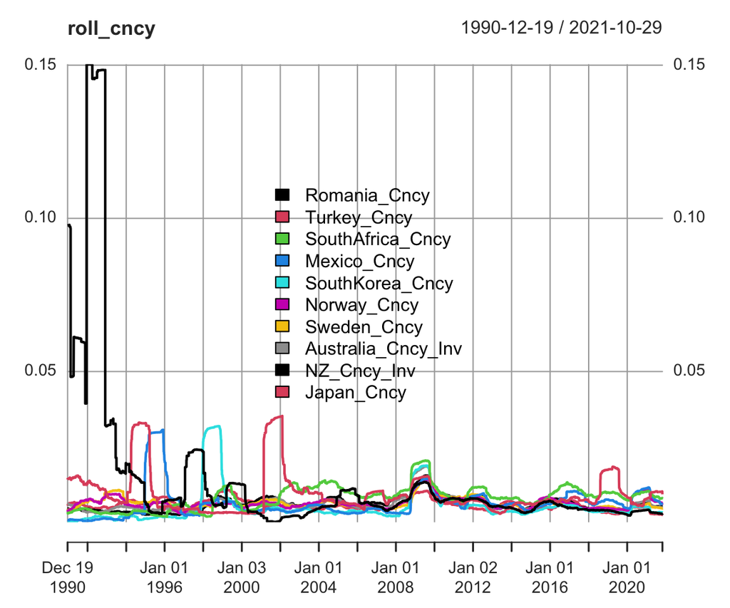

The market implied volatility further corroborates the findings from the actual volatility analysis. While the ZAR is not consistently the currency with the highest implied volatility, there are distinct periods where its implied volatility significantly exceeds that of other currencies, sometimes by a substantial margin. This pattern highlights the ZAR’s sensitivity to global market dynamics and its heightened vulnerability during periods of elevated risk or uncertainty.

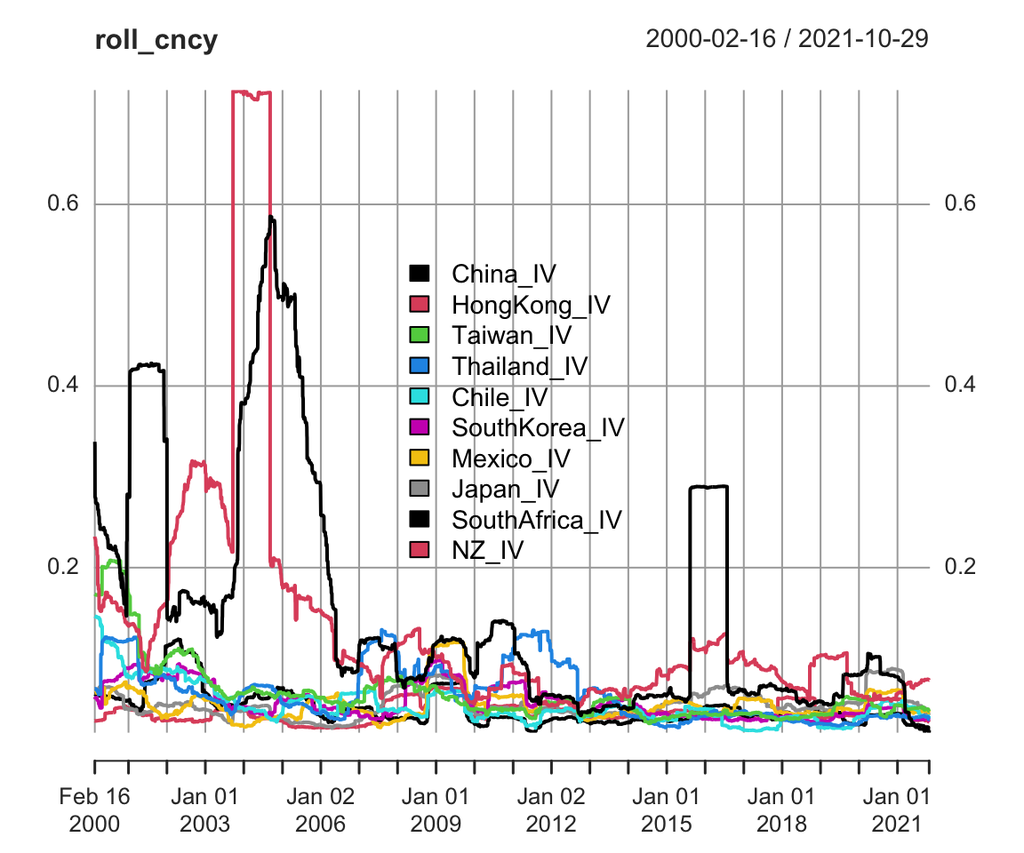

The regression results provide insights into the statement, “The ZAR has generally performed well during periods where G10 currency carry trades have been favourable and currency valuations relatively cheap. Globally, it has been one of the currencies that most benefit during periods where the Dollar is comparatively strong, indicating a risk-on sentiment.” However, the findings partially align with the statement and partially contradict it. The relationship between the ZAR and the G10 carry trade index (Carry_Index_norm) shows a negative coefficient (-0.086), indicating that ZAR tends to weaken when G10 carry trades are favorable. This contradicts the statement’s claim that ZAR performs well during such periods. A possible explanation could be that favorable G10 carry trades attract capital toward higher-yielding G10 currencies, making them more competitive against emerging market currencies like the ZAR. The positive coefficient for the dollar index (Dollar_Index_norm) at 0.844 supports the second part of the statement, which claims that ZAR benefits during periods of dollar strength. This relationship suggests that ZAR appreciates when the dollar strengthens, aligning with risk-on sentiment where emerging markets like South Africa attract investor interest. Lastly, the negative coefficient for volatility (Volatility_norm) at -0.0346 aligns with the broader implication of the statement that ZAR performs poorly during periods of uncertainty or risk aversion. High volatility reflects greater market uncertainty, which tends to weaken ZAR.

Regression Results

| term | estimate | std.error | statistic | p.value | significance |
| --- | --- | --- | --- | --- | --- |
| (Intercept) | 0.0000000 | 0.0076680 | 0.000000 | 1.0000000 |  |
| Carry_Index_norm | -0.0860865 | 0.0094969 | -9.064717 | 0.0000000 | *** |
| Dollar_Index_norm | 0.8441635 | 0.0078762 | 107.178930 | 0.0000000 | *** |
| Volatility_norm | -0.0346063 | 0.0092929 | -3.723945 | 0.0001986 | *** |

The plot of normalized variables reinforces the findings from the regression table, and to provide further clarity, the subsequent plot illustrates the rolling correlations.

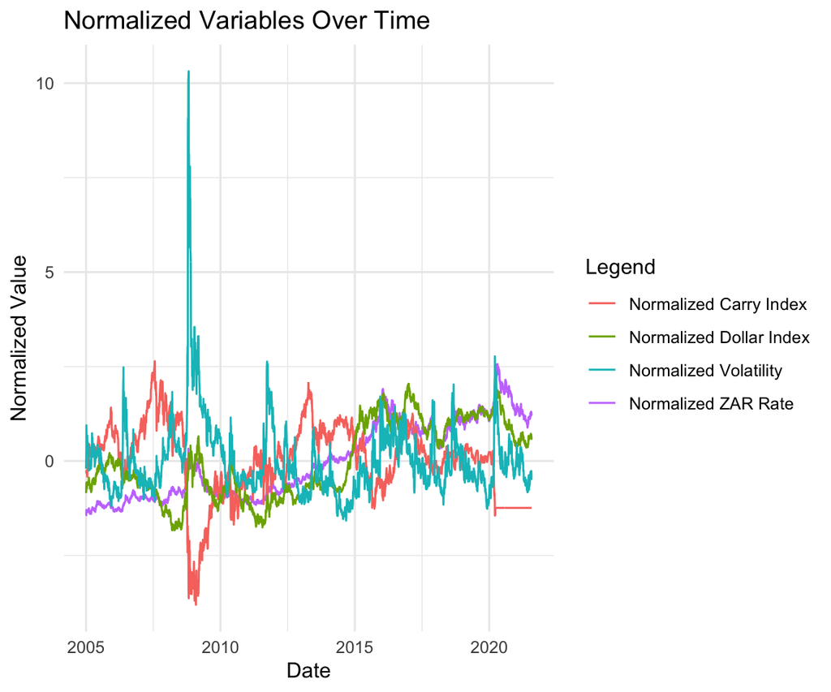

The rolling correlations in the chart highlight the dynamic relationships between the ZAR rate and the predictors over time, which adds nuance to the previous regression-based interpretation. The correlation between ZAR and the carry index (red line) fluctuates significantly, alternating between positive and negative values. This indicates that the relationship is not consistent and that ZAR does not always benefit during favorable carry trade periods, aligning with the earlier regression findings.

```
## $data
## # A tibble: 4,326 × 12
##    date       Carry_Index Dollar_Index Volatility ZAR_Rate Carry_Index_norm
##    <date>           <dbl>        <dbl>      <dbl>    <dbl>            <dbl>
##  1 2004-12-31        149.        1000        15.5     5.66           -0.301
##  2 2005-01-03        149.        1005.       16.5     5.65           -0.301
##  3 2005-01-04        150.        1018.       17.5     5.83           -0.272
##  4 2005-01-05        149.        1018.       18       5.92           -0.310
##  5 2005-01-06        150.        1025.       21       6.12           -0.258
##  6 2005-01-07        150.        1027.       20.5     6.09           -0.253
##  7 2005-01-10        149.        1024.       19       6.01           -0.288
##  8 2005-01-11        149.        1020.       17.9     5.96           -0.313
##  9 2005-01-12        149.        1011        18.8     5.95           -0.337
## 10 2005-01-13        149.        1013.       19       6.03           -0.349
## # ℹ 4,316 more rows
## # ℹ 6 more variables: Dollar_Index_norm <dbl>, Volatility_norm <dbl>,
## #   ZAR_Rate_norm <dbl>, Correlation_Carry <dbl>, Correlation_Dollar <dbl>,
## #   Correlation_Volatility <dbl>
##
## $plot
```

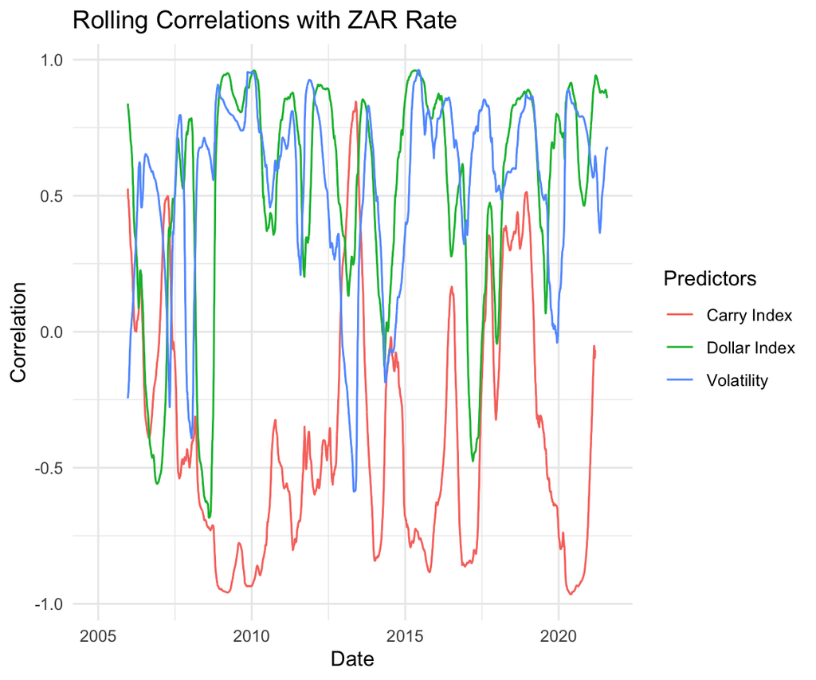

The scatterplots provide additional context to the relationships between the ZAR exchange rate and the predictors. The negative slope in the relationship between ZAR and the carry index (DBHVG10U) indicates that ZAR weakens when G10 carry trade returns are favorable, which is consistent with the regression findings but contradicts the statement that ZAR benefits during such periods. This may reflect a preference for G10 currencies over emerging market currencies like ZAR during favorable carry trade conditions. Conversely, the positive slope between ZAR and the dollar index (BBDXY) reinforces the idea that ZAR appreciates during periods of dollar strength, aligning with the statement’s claim that ZAR benefits during risk-on sentiment when the dollar strengthens. The relationship between ZAR and implied volatility shows a slightly positive slope, which is unexpected given the usual risk-off impact of volatility on emerging market currencies. This weak relationship suggests that volatility might have less direct influence on ZAR or that other factors mitigate its impact.

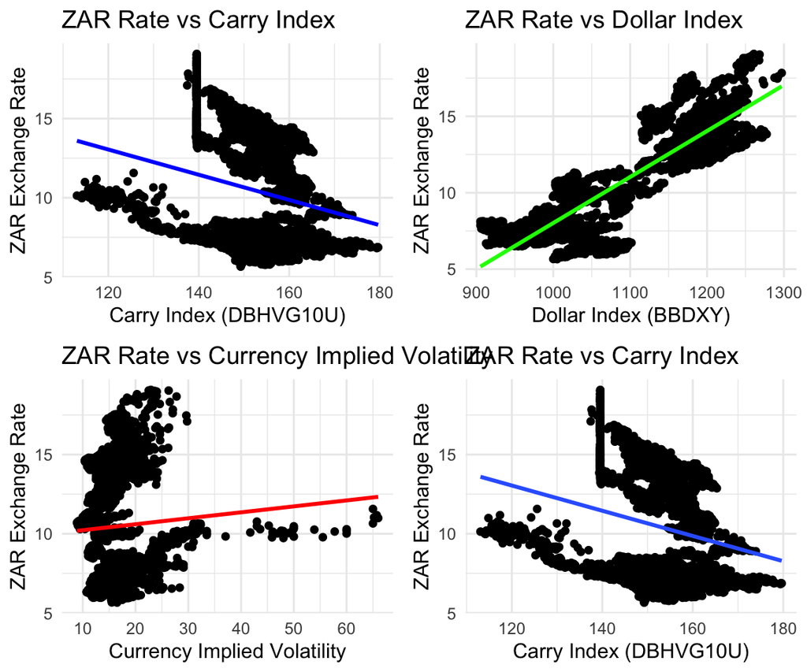